# Module 3 Applied Model Evaluation

Data Science using Python & R

3/21/2021

Desc:We will be working with the clothing_data_driven_training and clothing_data_ driven_test data sets. The task is to predict whether or not customers will respond to a phone/mail marketing campaign, based on three continuous predictors: 1. days since purchase 2. number of purchase visits 3. sales per visit

target variable: response (1=pos, 0=neg)

```r
#get datasets
setwd("C:/Users/Filipp/Documents/usd_data_sci/502_data mining/module1/website data sets")
train = read.table("clothing_data_driven_training",sep="\t",header = TRUE)
test =  read.table("clothing_data_driven_test",sep="\t",header=TRUE)

par(mfrow=c(2,1))
#sanity check
head(train)
```

```
##   Days.since.Purchase Number.of.Purchase.Visits Response Sales.per.Visit
## 1                   6                         4        1         64.5000
## 2                 327                         2        0         38.5000
## 3                  66                         8        0        105.7575
## 4                  49                         1        0         87.4400
## 5                  26                         2        0         60.0000
## 6                  98                         3        0        150.3267
```

```r
head(test)
```

```
##   Days.since.Purchase Number.of.Purchase.Visits Response Sales.per.Visit
## 1                 208                         2        0       184.23000
## 2                  64                         5        1       104.24000
## 3                  23                        12        1       138.62167
## 4                 144                         7        1        90.29714
## 5                 118                         1        0       172.99000
## 6                 276                         1        0        87.48000
```

we will be using a C5.0 model to create a decision tree for this instance.

```r
#install.packages("C50")
#requires all terminal nodes to have at least 75 cases.
library(C50)
```

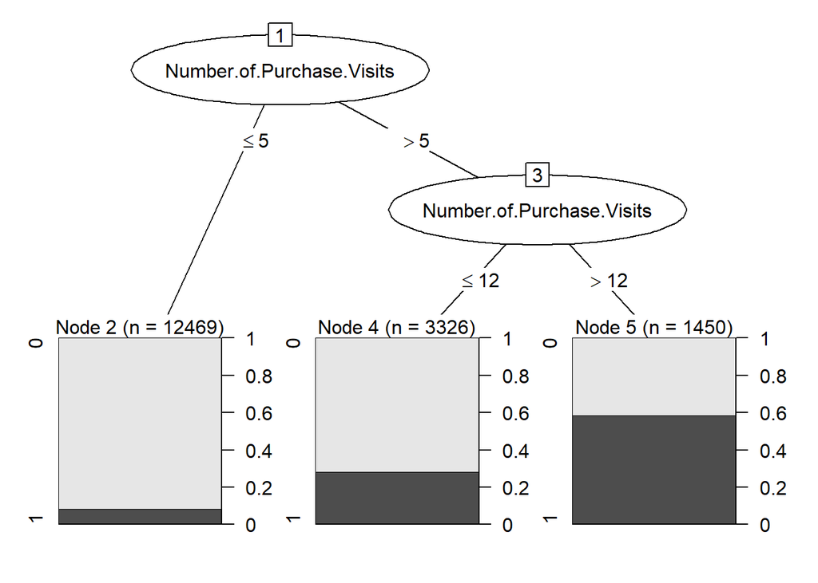

```r
#factorize
train$Response = as.factor(train$Response)

C5 <- C5.0(formula = Response ~ Days.since.Purchase + Sales.per.Visit + Number.of.Purchase.Visits,
           data = train,
           control = C5.0Control(minCases=75)
)
plot(C5)
```

```r
test.pred <- predict(object = C5, newdata = test)
results <- data.frame(test.pred,test$Response)
names(results) <- c("predicted","actual")
head(results)
```

```
##   predicted actual
## 1         0      0
## 2         0      1
## 3         0      1
## 4         0      1
## 5         0      0
## 6         0      0
```

Next we calculate TP, TN, etc.

```r
tp = length(which(results$predicted==1 & results$actual==1))
tn = length(which(results$predicted==0 & results$actual==0))
fp = length(which(results$predicted==1 & results$actual==0))
fn = length(which(results$predicted==0 & results$actual==1))
```

Given that these are in line with our textbook example, we can start calculating performance metrics for our binary classification. We begin by declaring our functions.

```r
accuracy <- function(tp,tn,fp,fn){
  n = sum(tp,tn,fp,fn)
  return(sum(tp,tn)/n)
}
sensitivity <- function(TP,FN){
    return (TP/(TP+FN))
}

specificity <- function(FP,TN){
    return (TN/(FP+TN))
}

precision <- function(TP,FP){
    return (TP/(TP+FP))
}

recall <- function(TN,FP){
    return (TN/(TN+FP))
}
```

From here, we can calculate each one.

```r
accuracy(tp,tn,fp,fn)
```

```
## [1] 0.8410074
```

```r
sensitivity(tp,fn)
```

```
## [1] 0.2804124
```

```r
specificity(fp,tn)
```

```
## [1] 0.9541294
```

```r
precision(tp,fp)
```

```
## [1] 0.5522843
```

```r
recall(tn,fp)
```

```
## [1] 0.9541294
```

Our accuracy is about 84%, and we can compare it to a baseline model of evaluating everything as negative to see how well we performed.

```r
#baseline model calculation:
baseline.accuracy <- (tn+fp) / nrow(results)
baseline.accuracy
```

```
## [1] 0.8320928
```

Our baseline accuracy is about 83%, which means the C5 classifier we constructed didn’t do particularly well. Furthermore, we also recognize that error costs are not uniform. We find that TP incurs a cost of =-40, FP incurs a cost of 10, and TN/FN incurs no cost.

We therefore adjust accordingly:

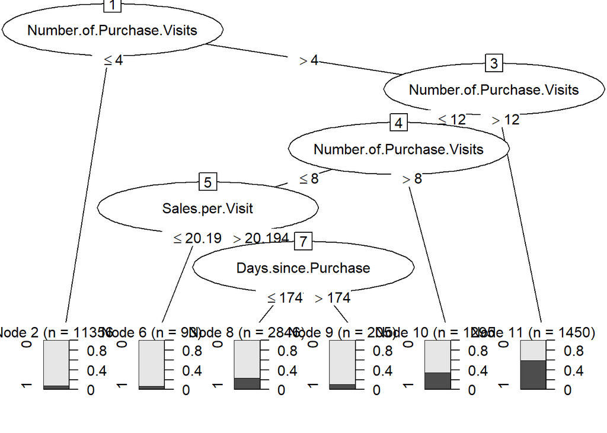

```r
cost.C5 <- matrix(c(0,4,1,0), byrow = TRUE, ncol=2)
dimnames(cost.C5) <- list(c("0", "1"), c("0", "1"))


C5.costs <- C5.0(Response ~ Days.since.Purchase +
Number.of.Purchase.Visits + Sales.per.Visit, data =
train, costs = cost.C5,control = C5.0Control(minCases=75))

plot(C5.costs)
```

Next, we predict.

```r
costs.pred <- predict(object = C5.costs, newdata = test)
results <- data.frame(costs.pred,test$Response)
names(results) <- c("predicted","actual")
head(results)
```

```
##   predicted actual
## 1         0      0
## 2         1      1
## 3         1      1
## 4         1      1
## 5         0      0
## 6         0      0
```

classification rate extraction:

```r
tp.cost = length(which(results$predicted==1 & results$actual==1))
tn.cost = length(which(results$predicted==0 & results$actual==0))
fp.cost = length(which(results$predicted==1 & results$actual==0))
fn.cost = length(which(results$predicted==0 & results$actual==1))

accuracy(tp.cost,tn.cost,fp.cost,fn.cost)
```

```
## [1] 0.7335122
```

```r
sensitivity(tp.cost,fn.cost)
```

```
## [1] 0.6824742
```

```r
specificity(fp.cost,tn.cost)
```

```
## [1] 0.7438111
```

```r
precision(tp.cost,fp.cost)
```

```
## [1] 0.3496171
```

```r
recall(tn.cost,fp.cost)
```

```
## [1] 0.7438111
```

our cost function for errors can be adjusted further by looking at the average sales per visit and understanding that our average profit gained for the true positive rate is actually 113.58. let’s adjust our costs accordingly:

```r
cost.C5 <- matrix(c(0,11.358,1,0), byrow = TRUE, ncol=2)
dimnames(cost.C5) <- list(c("0", "1"), c("0", "1"))


C5.costs <- C5.0(Response ~ Days.since.Purchase +
Number.of.Purchase.Visits + Sales.per.Visit, data =
train, costs = cost.C5,control = C5.0Control(minCases=75))

costs.pred <- predict(object = C5.costs, newdata = test)
results <- data.frame(costs.pred,test$Response)
names(results) <- c("predicted","actual")

tp.cost = length(which(results$predicted==1 & results$actual==1))
tn.cost = length(which(results$predicted==0 & results$actual==0))
fp.cost = length(which(results$predicted==1 & results$actual==0))
fn.cost = length(which(results$predicted==0 & results$actual==1))

accuracy(tp.cost,tn.cost,fp.cost,fn.cost)
```

```
## [1] 0.5193007
```

```r
sensitivity(tp.cost,fn.cost)
```

```
## [1] 0.893299
```

```r
specificity(fp.cost,tn.cost)
```

```
## [1] 0.4438319
```

```r
precision(tp.cost,fp.cost)
```

```
## [1] 0.244774
```

```r
recall(tn.cost,fp.cost)
```

```
## [1] 0.4438319
```

the models that made more positive predictions did better. Sensitivity is more important than specifity in this instance, so the model with the most recently adjusted costs (>100) did the best. Our best performing model had the highest sensitivity, which was model 3.